# R Notebook: Advanced methods

Montserrat Guillen

2018

# Introduction

In this document we do a more advanced Data Analysis linked to the article by S. Moro, P. Cortez and P. Rita. A Data-Driven Approach to Predict the Success of Bank Telemarketing. Decision Support Systems, Elsevier, 62:22-31, June 2014. The two datasets ontain similar information, but not exactly the same.. Here we will analyse the smaller data set (called **bank.csv**). The file can be downloaded from: https://archive.ics.uci.edu/ml/datasets/bank+marketing

or (for this course)

http://www.ub.edu/rfa/docs/DATA/bank.csv

We will see logistic regression, decision tree, random forest and svm. We could also try Bayesian networks and neural networks.

# Reading the data

```r
getwd()
```

```
## [1] "C:/Users/UBrisk/Desktop/BIG-DATA-DAY-2/clone"
```

```r
bank<-read.csv("bank.csv",header=T,sep=";", dec=".")
```

## Training and test data sets

We try to build a model with dividing training data and test data set. We divide 75% of whole bank data set as training data, and rest 25% of bank data set.

```r
set.seed(123456789)
random<-sample(1:nrow(bank))
num.bank.training<-as.integer(0.75*length(random))
bank.indices<-random[1:num.bank.training]
train<-bank[bank.indices,]
testing.indices<-random[(num.bank.training+1):length(random)]
testing.set<-bank[testing.indices,]
```

# Logistic regression

## Full model

We estimate the full model

```r
logis<-glm(y ~ ., data=train,family=binomial)
summary(logis)
```

```
##
## Call:
## glm(formula = y ~ ., family = binomial, data = train)
##
## Deviance Residuals:
##     Min       1Q   Median       3Q      Max
## -3.0280  -0.3874  -0.2585  -0.1516   3.0401
##
## Coefficients:
##                      Estimate Std. Error z value Pr(>|z|)
## (Intercept)        -2.720e+00  6.987e-01  -3.894 9.88e-05 ***
## age                 1.410e-03  8.070e-03   0.175   0.8613
## jobblue-collar     -4.045e-01  2.767e-01  -1.462   0.1438
## jobentrepreneur    -3.145e-01  4.519e-01  -0.696   0.4864
## jobhousemaid       -5.562e-01  4.858e-01  -1.145   0.2523
## jobmanagement      -2.128e-01  2.835e-01  -0.751   0.4528
## jobretired          3.727e-01  3.629e-01   1.027   0.3045
## jobself-employed   -1.625e-01  3.944e-01  -0.412   0.6804
## jobservices        -1.188e-01  3.086e-01  -0.385   0.7001
## jobstudent         -1.765e-02  4.659e-01  -0.038   0.9698
## jobtechnician      -2.234e-01  2.682e-01  -0.833   0.4050
## jobunemployed      -8.416e-01  5.020e-01  -1.677   0.0936 .
## jobunknown          1.838e-01  6.533e-01   0.281   0.7785
## maritalmarried     -4.818e-01  1.986e-01  -2.425   0.0153 *
## maritalsingle      -2.682e-01  2.337e-01  -1.148   0.2510
## educationsecondary  1.036e-02  2.299e-01   0.045   0.9640
## educationtertiary   3.023e-01  2.673e-01   1.131   0.2581
## educationunknown   -4.279e-01  3.990e-01  -1.072   0.2835
## defaultyes          7.211e-01  4.802e-01   1.502   0.1331
## balance            -2.523e-06  1.863e-05  -0.135   0.8923
## housingyes         -2.668e-01  1.587e-01  -1.681   0.0928 .
## loanyes            -4.262e-01  2.158e-01  -1.975   0.0483 *
## contacttelephone    1.618e-02  2.653e-01   0.061   0.9514
## contactunknown     -1.574e+00  2.702e-01  -5.827 5.66e-09 ***
## day                 1.494e-02  9.519e-03   1.570   0.1165
## monthaug           -6.274e-02  2.975e-01  -0.211   0.8330
## monthdec            3.881e-02  8.088e-01   0.048   0.9617
## monthfeb            5.898e-01  3.412e-01   1.728   0.0839 .
## monthjan           -5.631e-01  4.249e-01  -1.325   0.1851
## monthjul           -5.619e-01  2.930e-01  -1.918   0.0551 .
```

[output cut: 8 more lines]

```
## pdays              -1.185e-04  1.186e-03  -0.100   0.9204
## previous           -2.134e-02  4.223e-02  -0.505   0.6133
## poutcomeother       5.990e-01  3.037e-01   1.972   0.0486 *
## poutcomesuccess     2.434e+00  3.224e-01   7.549 4.37e-14 ***
## poutcomeunknown    -1.422e-01  3.674e-01  -0.387   0.6987
## ---
## Signif. codes:  0 '***' 0.001 '**' 0.01 '*' 0.05 '.' 0.1 ' ' 1
##
## (Dispersion parameter for binomial family taken to be 1)
##
##     Null deviance: 2440.3  on 3389  degrees of freedom
## Residual deviance: 1633.2  on 3347  degrees of freedom
## AIC: 1719.2
##
## Number of Fisher Scoring iterations: 6
```

## Boxplots

Boxplot for dependent variable -> however, since y is categorical variable, no need to transformed

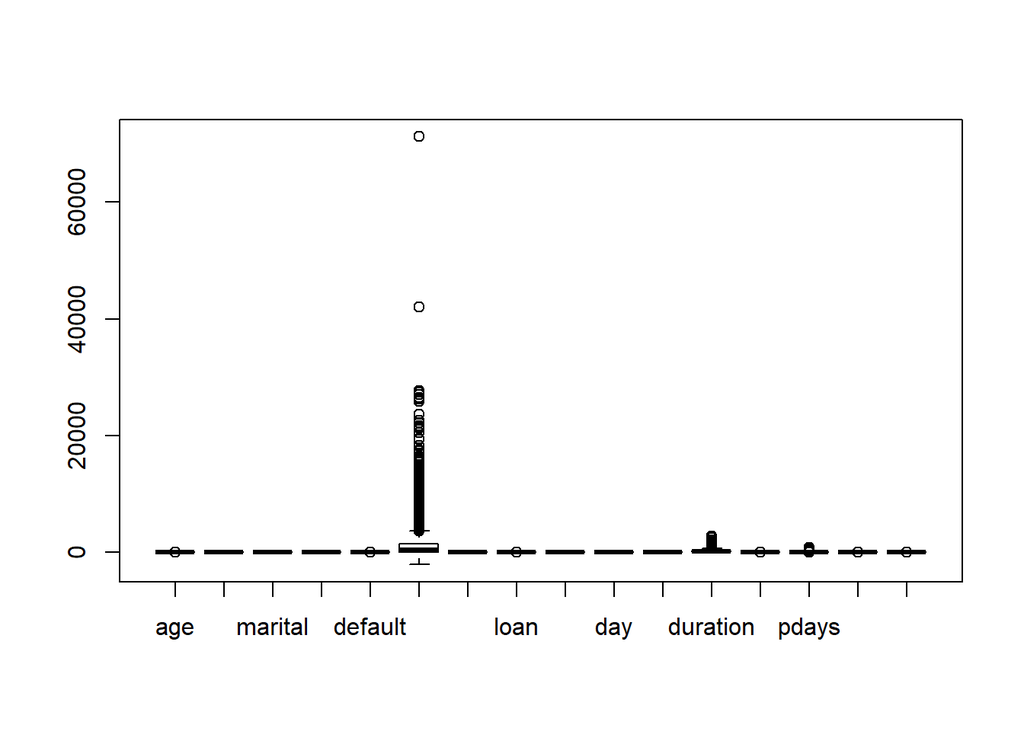

```r
boxplot(train[,1:(ncol(bank)-1)])
```

```r
bank1<-train
bank1$dffits<-0
bank1$dffits<-dffits(logis)
bank2<-bank1[!bank1$dffits>2*sqrt(ncol(bank)/nrow(bank)),]

bank1$dfitts<-NULL
bank2$dfitts<-NULL
bank1$out<-NULL
bank2$out<-NULL
```

## Outliers

We removed some influential outliers

```r
logit<-glm(y~.,data=bank2,family=binomial)
```

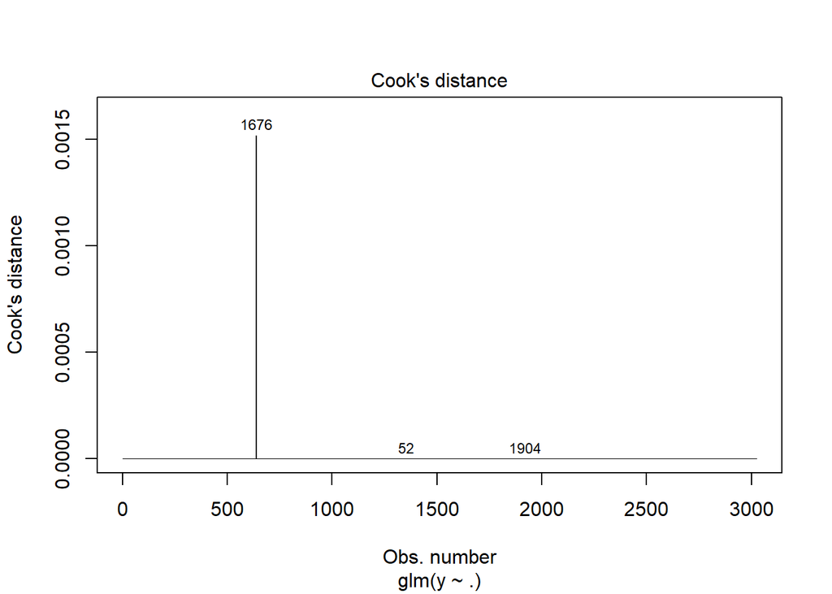

```r
plot(logit,which=4)
```

## We run a new model

```r
bank3<-bank2[-c(1676, 52, 1904),]

logit.2<-glm(y~factor(contact) + factor(month) + duration +  balance +  previous +   factor(loan)+ factor(default) ,data=bank3,family=binomial)
summary(logit.2)
```

```
##
## Call:
## glm(formula = y ~ factor(contact) + factor(month) + duration +
##     balance + previous + factor(loan) + factor(default), family = binomial,
##     data = bank3)
##
## Deviance Residuals:
##      Min        1Q    Median        3Q       Max
## -2.46820  -0.03438  -0.01654  -0.00399   2.87913
##
## Coefficients:
##                            Estimate Std. Error z value Pr(>|z|)
## (Intercept)              -8.392e+00  1.223e+00  -6.864 6.67e-12 ***
## factor(contact)telephone  9.074e-01  8.864e-01   1.024   0.3060
## factor(contact)unknown   -2.441e+00  1.377e+00  -1.773   0.0763 .
## factor(month)aug          3.483e-01  1.160e+00   0.300   0.7640
## factor(month)dec          6.041e-01  1.871e+00   0.323   0.7468
## factor(month)feb         -6.285e-01  1.942e+00  -0.324   0.7462
## factor(month)jan         -1.707e-03  1.571e+00  -0.001   0.9991
## factor(month)jul         -1.195e-01  1.295e+00  -0.092   0.9265
## factor(month)jun          1.480e+00  1.389e+00   1.066   0.2866
## factor(month)mar          5.576e+00  1.276e+00   4.369 1.25e-05 ***
## factor(month)may         -2.183e+00  1.444e+00  -1.511   0.1307
## factor(month)nov         -1.868e+01  1.321e+03  -0.014   0.9887
## factor(month)oct          2.386e+00  1.451e+00   1.644   0.1002
## factor(month)sep         -1.482e+01  5.001e+03  -0.003   0.9976
## duration                  6.393e-03  7.930e-04   8.062 7.50e-16 ***
## balance                  -3.603e-04  2.631e-04  -1.370   0.1708
## previous                  1.635e-01  9.338e-02   1.751   0.0800 .
## factor(loan)yes          -1.220e+00  1.377e+00  -0.886   0.3754
## factor(default)yes        1.825e+00  2.191e+00   0.833   0.4049
## ---
## Signif. codes:  0 '***' 0.001 '**' 0.01 '*' 0.05 '.' 0.1 ' ' 1
##
## (Dispersion parameter for binomial family taken to be 1)
##
##     Null deviance: 327.191  on 3020  degrees of freedom
## Residual deviance:  93.539  on 3002  degrees of freedom
## AIC: 131.54
##
## Number of Fisher Scoring iterations: 20
```

Check multicollinearity and variable selection

```r
table(bank3$y)
```

```
##
##   no  yes
## 2992   29
```

```r
library("stats")
library("MASS")
stepAIC(logit.2,k=2)
```

```
## Start:  AIC=131.54
## y ~ factor(contact) + factor(month) + duration + balance + previous +
##     factor(loan) + factor(default)
```

```
##                   Df Deviance    AIC
## - factor(default)  1   94.212 130.21
## - factor(loan)     1   94.431 130.43
## <none>                 93.539 131.54
## - previous         1   96.186 132.19
## - balance          1   96.252 132.25
## - factor(contact)  2   98.449 132.45
## - factor(month)   11  144.933 160.93
## - duration         1  271.016 307.02
```

```
##
## Step:  AIC=130.21
## y ~ factor(contact) + factor(month) + duration + balance + previous +
##     factor(loan)
```

```
##                   Df Deviance    AIC
## - factor(loan)     1   95.153 129.15
## <none>                 94.212 130.21
## - factor(contact)  2   98.748 130.75
## - previous         1   96.929 130.93
## - balance          1   97.052 131.05
## - factor(month)   11  146.093 160.09
## - duration         1  271.975 305.98
```

```
##
## Step:  AIC=129.15
## y ~ factor(contact) + factor(month) + duration + balance + previous
```

```
##                   Df Deviance    AIC
## <none>                 95.153 129.15
## - previous         1   97.834 129.83
## - balance          1   97.892 129.89
## - factor(contact)  2   99.943 129.94
## - factor(month)   11  148.431 160.43
## - duration         1  273.157 305.16
```

```
##
## Call:  glm(formula = y ~ factor(contact) + factor(month) + duration +
##     balance + previous, family = binomial, data = bank3)
##
## Coefficients:
##              (Intercept)  factor(contact)telephone
##               -8.377e+00                 8.993e-01
##   factor(contact)unknown          factor(month)aug
##               -2.277e+00                 3.163e-01
##         factor(month)dec          factor(month)feb
##                6.259e-01                -6.240e-01
##         factor(month)jan          factor(month)jul
##                8.148e-04                -6.775e-01
##         factor(month)jun          factor(month)mar
##                1.552e+00                 5.569e+00
##         factor(month)may          factor(month)nov
##               -2.215e+00                -1.865e+01
##         factor(month)oct          factor(month)sep
##                2.338e+00                -1.485e+01
##                 duration                   balance
##                6.363e-03                -3.562e-04
##                 previous
##                1.599e-01
##
## Degrees of Freedom: 3020 Total (i.e. Null);  3004 Residual
## Null Deviance:       327.2
## Residual Deviance: 95.15     AIC: 129.2
```

From AIC test, the best model would be glm(formula = y ~ factor(contact) + factor(month) + duration + balance + previous, family = binomial, data = bank3)

```r
logit.aic<- glm(formula = y ~ factor(contact) + factor(month) + duration +
    balance + previous, family = binomial, data = bank3)
summary(logit.aic)
```

```
##
## Call:
## glm(formula = y ~ factor(contact) + factor(month) + duration +
##     balance + previous, family = binomial, data = bank3)
##
## Deviance Residuals:
##      Min        1Q    Median        3Q       Max
## -2.44204  -0.03419  -0.01839  -0.00445   2.88222
##
## Coefficients:
##                            Estimate Std. Error z value Pr(>|z|)
## (Intercept)              -8.377e+00  1.200e+00  -6.982 2.92e-12 ***
## factor(contact)telephone  8.993e-01  8.847e-01   1.016   0.3094
## factor(contact)unknown   -2.277e+00  1.303e+00  -1.748   0.0805 .
## factor(month)aug          3.163e-01  1.142e+00   0.277   0.7819
## factor(month)dec          6.259e-01  1.862e+00   0.336   0.7368
## factor(month)feb         -6.240e-01  1.914e+00  -0.326   0.7444
## factor(month)jan          8.148e-04  1.560e+00   0.001   0.9996
## factor(month)jul         -6.775e-01  1.200e+00  -0.565   0.5723
## factor(month)jun          1.552e+00  1.365e+00   1.137   0.2554
## factor(month)mar          5.569e+00  1.262e+00   4.414 1.01e-05 ***
## factor(month)may         -2.215e+00  1.426e+00  -1.553   0.1204
## factor(month)nov         -1.865e+01  1.326e+03  -0.014   0.9888
## factor(month)oct          2.338e+00  1.444e+00   1.619   0.1054
## factor(month)sep         -1.485e+01  5.023e+03  -0.003   0.9976
## duration                  6.363e-03  7.787e-04   8.172 3.04e-16 ***
## balance                  -3.562e-04  2.584e-04  -1.379   0.1680
## previous                  1.599e-01  9.045e-02   1.768   0.0770 .
## ---
## Signif. codes:  0 '***' 0.001 '**' 0.01 '*' 0.05 '.' 0.1 ' ' 1
##
## (Dispersion parameter for binomial family taken to be 1)
##
##     Null deviance: 327.191  on 3020  degrees of freedom
## Residual deviance:  95.153  on 3004  degrees of freedom
## AIC: 129.15
##
## Number of Fisher Scoring iterations: 20
```

If we use BIC, the function is stepAIC(logit.2,k=log(length(bank3[,1])))

```r
stepAIC(logit.2,k=log(length(bank3[,1])))
```

```
## Start:  AIC=245.79
## y ~ factor(contact) + factor(month) + duration + balance + previous +
##     factor(loan) + factor(default)
```

```
##                   Df Deviance    AIC
## - factor(month)   11  144.933 209.04
## - factor(contact)  2   98.449 234.68
## - factor(default)  1   94.212 238.45
## - factor(loan)     1   94.431 238.67
## - previous         1   96.186 240.43
## - balance          1   96.252 240.49
## <none>                 93.539 245.79
## - duration         1  271.016 415.26
##
## Step:  AIC=209.04
## y ~ factor(contact) + duration + balance + previous + factor(loan) +
##     factor(default)
##
##                   Df Deviance    AIC
## - factor(contact)  2   153.58 201.66
## - factor(default)  1   146.09 202.19
## - previous         1   146.40 202.50
## - balance          1   146.72 202.82
## - factor(loan)     1   147.25 203.34
## <none>                 144.93 209.04
## - duration         1   313.17 369.26
##
## Step:  AIC=201.66
## y ~ duration + balance + previous + factor(loan) + factor(default)
##
##                   Df Deviance    AIC
## - factor(default)  1   153.93 194.00
## - factor(loan)     1   155.50 195.56
## - balance          1   155.64 195.71
## - previous         1   157.04 197.11
## <none>                 153.58 201.66
## - duration         1   315.97 356.04
##
## Step:  AIC=194
## y ~ duration + balance + previous + factor(loan)
##
##                Df Deviance    AIC
## - factor(loan)  1   155.89 187.95
## - balance       1   156.05 188.10
```

[output cut: 12 more lines]

```
##
## Step:  AIC=181.77
## y ~ duration + previous
##
##            Df Deviance    AIC
## - previous  1   162.30 178.33
## <none>          157.73 181.77
## - duration  1   322.27 338.29
##
## Step:  AIC=178.33
## y ~ duration
##
##            Df Deviance    AIC
## <none>          162.30 178.33
## - duration  1   327.19 335.20
```

```
##
## Call:  glm(formula = y ~ duration, family = binomial, data = bank3)
##
## Coefficients:
## (Intercept)     duration
##   -7.376387     0.004863
##
## Degrees of Freedom: 3020 Total (i.e. Null);  3019 Residual
## Null Deviance:       327.2
## Residual Deviance: 162.3     AIC: 166.3
```

From BIC test the best model would be glm(formula = y ~duration, family = binomial, data = bank3)

```r
logit.bic<-glm(formula = y ~duration, family = binomial, data = bank3)

summary(logit.bic)
```

```
##
## Call:
## glm(formula = y ~ duration, family = binomial, data = bank3)
##
## Deviance Residuals:
##     Min       1Q   Median       3Q      Max
## -1.8249  -0.0704  -0.0530  -0.0445   3.5615
##
## Coefficients:
##               Estimate Std. Error z value Pr(>|z|)
## (Intercept) -7.3763867  0.4850989  -15.21   <2e-16 ***
## duration     0.0048633  0.0004541   10.71   <2e-16 ***
## ---
## Signif. codes:  0 '***' 0.001 '**' 0.01 '*' 0.05 '.' 0.1 ' ' 1
##
## (Dispersion parameter for binomial family taken to be 1)
##
##     Null deviance: 327.19  on 3020  degrees of freedom
## Residual deviance: 162.30  on 3019  degrees of freedom
## AIC: 166.3
##
## Number of Fisher Scoring iterations: 9
```

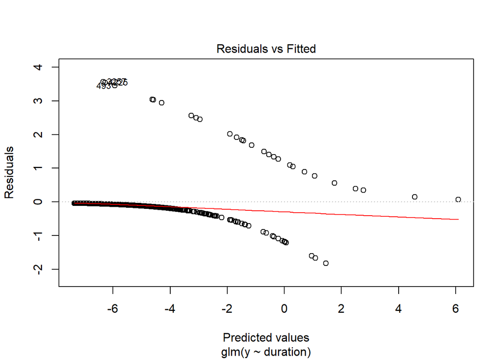

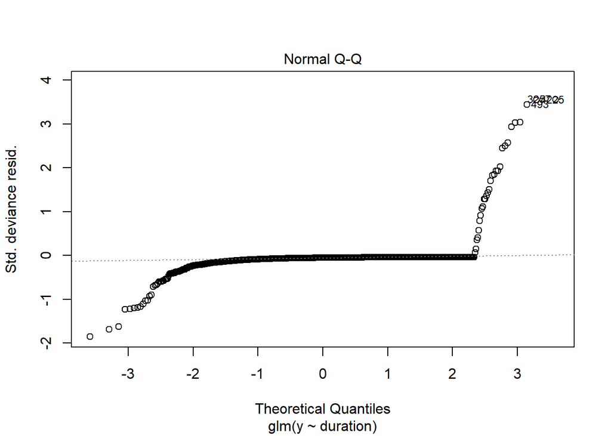

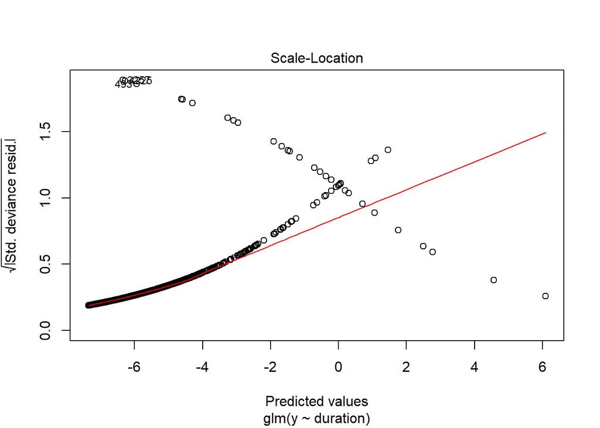

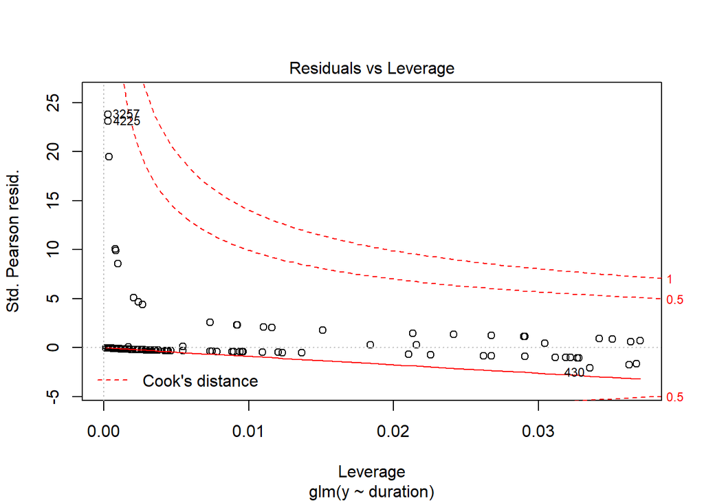

```r
plot(logit.bic)
```

## Predictive accuracy calculation

Let’s do the predictions now:

```r
prediction <- data.frame(predict(logit.bic,bank3,type="response"))
prediction[prediction<0.5]=0
prediction[prediction>=0.5]=1
predictions <- data.frame(Prediction = as.numeric(prediction[,1]),Actual = as.numeric(bank3$y)-1)
predictions$Correct <- (predictions$Actual == predictions$Prediction)
logistic_accuracy<-table(predictions$Correct)/length(predictions$Correct)*100
logistic_accuracy
```

```
##
##      FALSE       TRUE
##  0.8606422 99.1393578
```

```r
table(predictions$Actual, predictions$Prediction)
```

```
##
##        0    1
##   0 2986    6
##   1   20    9
```

The accuracy is 99.14% which is really high.

```r
prediction.test<-data.frame(predict(logit.bic,testing.set,type="response"))
prediction.test[prediction.test<0.5]=0
prediction.test[prediction.test>=0.5]=1
predictions.test <- data.frame(Prediction = as.numeric(prediction.test[,1]),Actual = as.numeric(testing.set$y)-1)
predictions.test$Correct <- (predictions.test$Actual == predictions.test$Prediction)
logistic_accuracy.test<-table(predictions.test$Correct)/length(predictions.test$Correct)*100
logistic_accuracy.test
```

```
##
##    FALSE     TRUE
## 11.05217 88.94783
```

```r
table(predictions.test$Actual, predictions.test$Prediction)
```

```
##
##        0    1
##   0 1003    2
##   1  123    3
```

The accuracy is 88.95% which is less than prediction of training.set.

# Decision tree model

Next one would be decision tree model

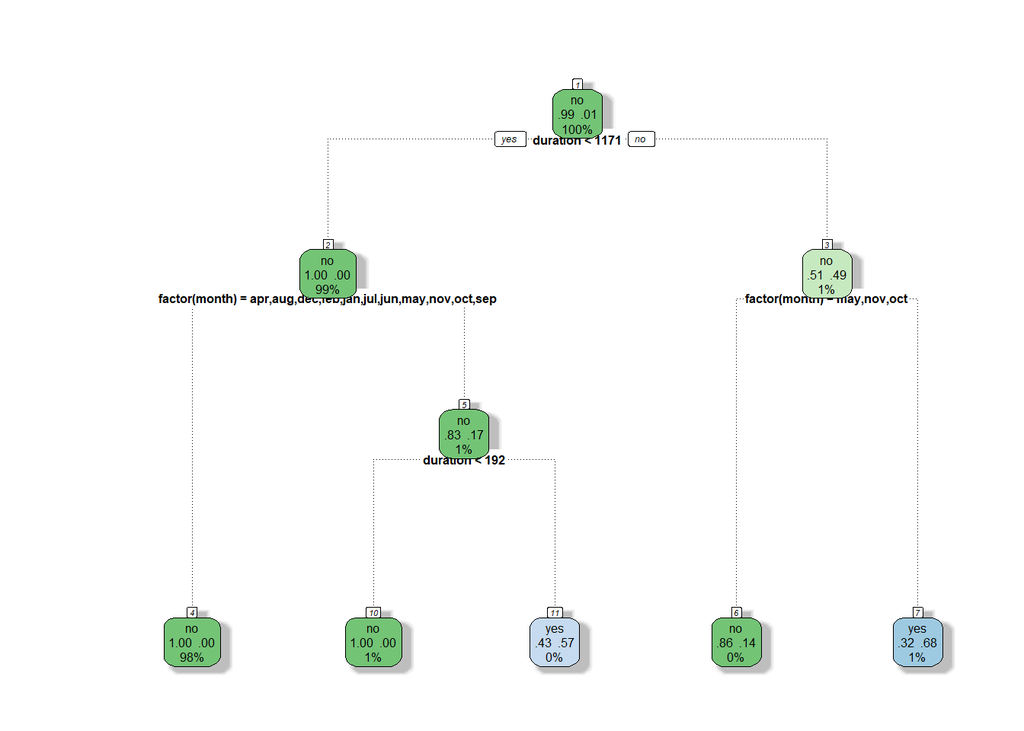

```r
#install.packages("ElemStatLearn")
#install.packages("tree")
#install.packages("rpart")
#install.packages("rattle")
#install.packages("rpart.plot")
#install.packages("RcolorBrewer")

library(ElemStatLearn)
library(tree)
require(rpart)
library(rpart)
tree <- rpart(y~factor(contact) + factor(month) + duration +
    balance + previous, data=bank3, method="class")
library(rattle)
library(rpart.plot)
library(RColorBrewer)
fancyRpartPlot(tree,main = "", sub = "",cex=0.5)
```

```r
# proportion of "no", "yes" and sample proportion
printcp(tree)
```

```
##
## Classification tree:
## rpart(formula = y ~ factor(contact) + factor(month) + duration +
##     balance + previous, data = bank3, method = "class")
##
## Variables actually used in tree construction:
## [1] duration      factor(month)
##
## Root node error: 29/3021 = 0.0095995
##
## n= 3021
##
##         CP nsplit rel error  xerror    xstd
## 1 0.155172      0   1.00000 1.00000 0.18480
## 2 0.017241      2   0.68966 0.93103 0.17838
## 3 0.010000      4   0.65517 0.89655 0.17507
```

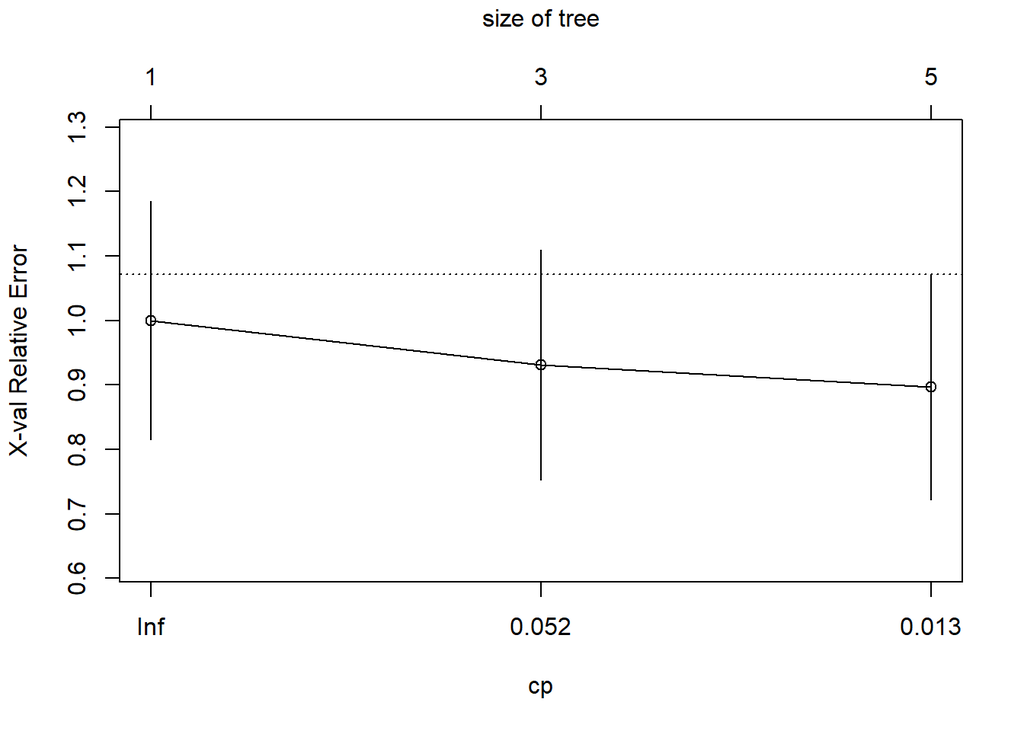

```r
plotcp(tree)
```

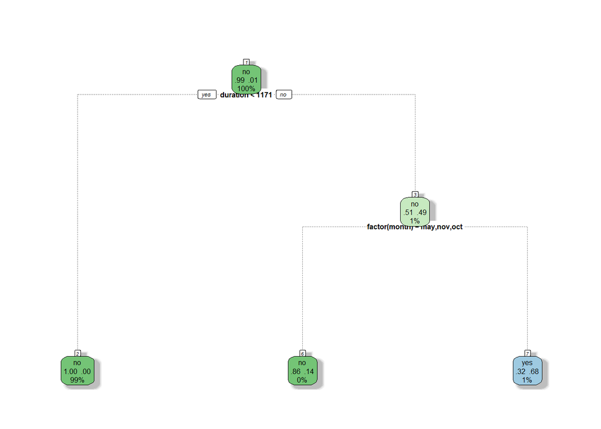

```r
tree.prune = prune(tree, cp = 0.05)
fancyRpartPlot(tree.prune,main = "", sub = "",cex=0.5)
```

## Predictive accuracy calculation

Make prediction

```r
prediction.tree <- data.frame(predict(tree.prune, bank3, type = "class"))
predictions.tree <- data.frame(Prediction = as.numeric(prediction.tree[,1])-1,Actual = as.numeric(bank3$y)-1)
predictions.tree$Correct <- (predictions.tree$Actual == predictions.tree$Prediction)
Tree_Accuracy <- table(predictions.tree$Correct)/length(predictions.tree$Correct)*100
Tree_Accuracy
```

```
##
##      FALSE       TRUE
##  0.6620324 99.3379676
```

predict with test

```r
prediction.tree.test<-data.frame(predict(tree.prune,testing.set,
     type="class"))
predictions.tree.t <- data.frame(Prediction = as.numeric(prediction.tree.test[,1])-1,Actual = as.numeric(testing.set$y)-1)
predictions.tree.t$Correct <- (predictions.tree.t$Actual == predictions.tree.t$Prediction)
Tree_Accuracy.t <- table(predictions.tree.t$Correct)/length(predictions.tree.t$Correct)*100
Tree_Accuracy.t
```

```
##
##    FALSE     TRUE
## 11.05217 88.94783
```

# Random forest

Random Forrest

```r
#install.packages("randomForest")
library(randomForest)
forest<-randomForest(as.factor(y)~contact + month+ duration + balance+
                       previous,data=bank2, importance=TRUE, ntree=100)
#nstead of specifying method="class" as with rpart, we force the model
#to predict our classification by temporarily changing our target
#variable to a factor with only two levels using as.factor(). The
#importance=TRUE argument allows us to inspect variable importance
#as we'll see, and the ntree argument specifies how many trees we want to grow.
#If you were working with a larger dataset you may want to reduce
#the number of trees, at least for initial exploration, or restrict the complexity
#of each tree using nodesize as well as reduce the number of rows sampled with
#sampsize. You can also override the default number of variables to choose
#from with mtry, but the default is the square root of the total number
#available and that should work just fine. Since we only have a small
#dataset to play with, we can grow a large number of trees and not worry
#too much about their complexity, it will still run pretty fast.
summary(forest)
```

```
##                 Length Class  Mode
## call               5   -none- call
## type               1   -none- character
## predicted       3024   factor numeric
## err.rate         300   -none- numeric
## confusion          6   -none- numeric
## votes           6048   matrix numeric
## oob.times       3024   -none- numeric
## classes            2   -none- character
## importance        20   -none- numeric
## importanceSD      15   -none- numeric
## localImportance    0   -none- NULL
## proximity          0   -none- NULL
## ntree              1   -none- numeric
## mtry               1   -none- numeric
## forest            14   -none- list
## y               3024   factor numeric
## test               0   -none- NULL
## inbag              0   -none- NULL
## terms              3   terms  call
```

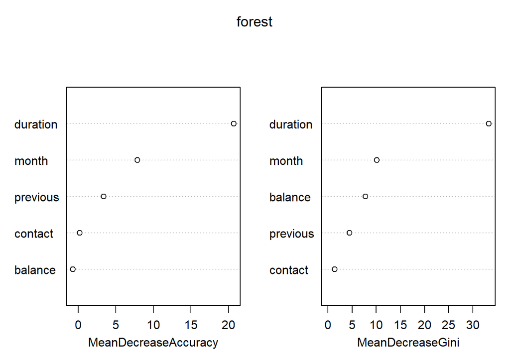

```r
varImpPlot(forest)
```

```r
#There's two types of importance measures shown above.
#The accuracy one tests to see how worse the model
#performs without each variable, so a high decrease
#in accuracy would be expected for very predictive variables.
#The Gini one digs into the mathematics behind decision trees,
#but essentially measures how pure the nodes are at the end of the tree.
#Again it tests to see the result if each variable is taken out and
#a high score means the variable was important.
```

## Predictive accuracy calculation

Make prediction

```r
prediction.forest <- data.frame(predict(forest, bank2, type = "class"))
predictions.forest <- data.frame(Prediction = as.numeric(prediction.forest[,1])-1,Actual = as.numeric(bank2$y)-1)
predictions.forest$Correct <- (predictions.forest$Actual == predictions.forest$Prediction)
forest_Accuracy <- table(predictions.forest$Correct)/length(predictions.forest$Correct)*100
forest_Accuracy
```

```
##
## TRUE
##  100
```

predict with test

```r
prediction.forest.test<-data.frame(predict(forest,testing.set,type="class"))
predictions.forest.t <- data.frame(Prediction = as.numeric(prediction.forest.test[,1])-1,Actual = as.numeric(testing.set$y)-1)
predictions.forest.t$Correct <- (predictions.forest.t$Actual == predictions.forest.t$Prediction)
Forest_Accuracy.t <- table(predictions.forest.t$Correct)/length(predictions.forest.t$Correct)*100
Forest_Accuracy.t
```

```
##
##    FALSE     TRUE
## 11.40584 88.59416
```

# Support vector machine

Support vector machine

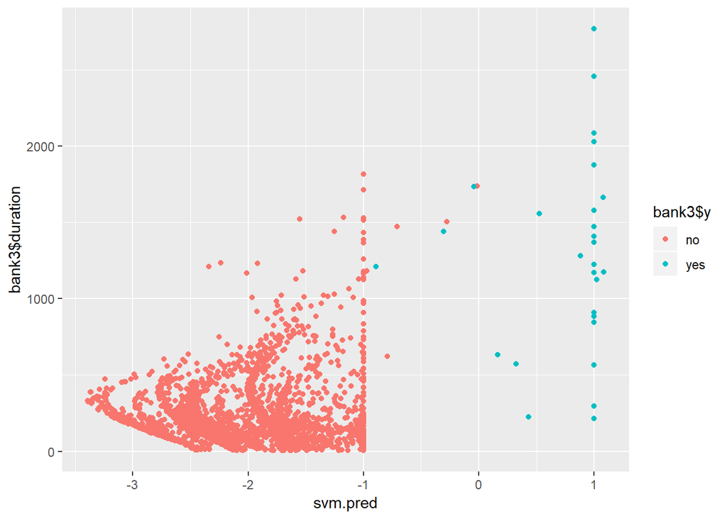

```r
#install.packages("e1071")
#install.packages("kernlab")

library(e1071)
library(kernlab)

svm.fit = ksvm(y~ contact + month+ duration + balance+
                       previous, data = bank3, type="C-svc", kernel="rbfdot", C=10)
svm.pred <- predict(svm.fit, bank3, type = "decision")
library(ggplot2)
qplot(svm.pred, bank3$duration, color=bank3$y)
```

```r
summary(svm.fit)
```

```
## Length  Class   Mode
##      1   ksvm     S4
```

## Predictive accuracy calculation

Make prediction

```r
prediction.svm <- data.frame(predict(svm.fit, bank3))
predictions.svm <- data.frame(Prediction = as.numeric(prediction.svm[,1])-1,Actual = as.numeric(bank3$y)-1)
predictions.svm$Correct <- (predictions.svm$Actual == predictions.svm$Prediction)
svm_Accuracy <- table(predictions.svm$Correct)/length(predictions.svm$Correct)*100
svm_Accuracy
```

```
##
##       FALSE        TRUE
##  0.09930487 99.90069513
```

predict with test

```r
prediction.svm.test<-data.frame(predict(svm.fit,testing.set))
predictions.svm.t <- data.frame(Prediction = as.numeric(prediction.svm.test[,1])-1,Actual = as.numeric(testing.set$y)-1)
predictions.svm.t$Correct <- (predictions.svm.t$Actual == predictions.svm.t$Prediction)
svm_Accuracy.t <- table(predictions.svm.t$Correct)/length(predictions.svm.t$Correct)*100
svm_Accuracy.t
```

```
##
##    FALSE     TRUE
## 11.40584 88.59416
```

```r
save.image("Prog-09-allobjects.Rdata")
```